# 1、腾讯云服务器开通

https://cloud.tencent.com/

[figure not shown]

产品》云服务器》立即选购 自定义配置

[figure not shown]

[figure not shown]

自定义配置

[figure not shown]

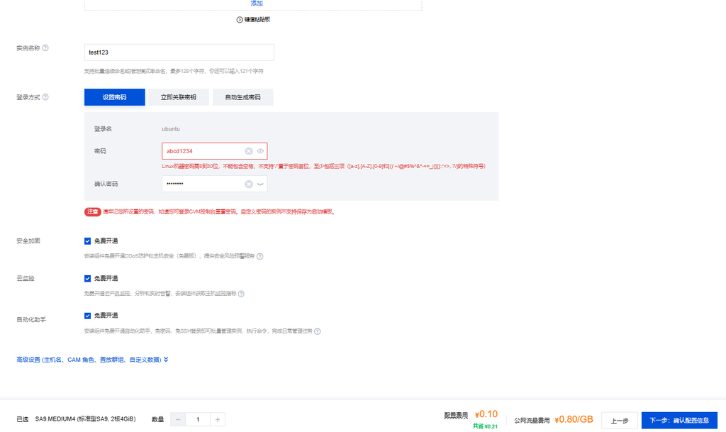

[figure not shown]

在控制台可以控制开关机

[figure not shown]

通过腾讯云的OrcaTerm进入系统

[figure not shown]

# 2、如何安装PostgreSQL

## 2.1 在Ubuntu系统安装PostgreSQL

### 1）安装命令

sudo apt install postgresql

### 2）验证

psql --version

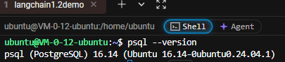

### 3）查看状态与端口占用

#### 查看状态

systemctl status postgresql.service

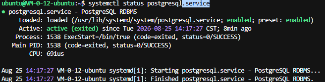

#### 查看端口占用

sudo netstat -tunlp | grep postgres

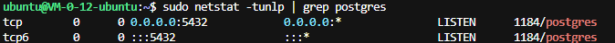

- 两个 socket 都在 5432 端口，分别服务 IPv4、IPv6 客户端。
- 外部机器不管是 ipv4 还是 ipv6 都可以连 postgres。

## 2.2 创建用户和数据库

### 1）启动客户端

切换到postgresql并执行psql命令，客户端即可启动

sudo -u postgres psql

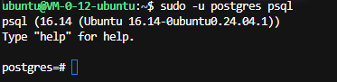

### 2）创建用户

CREATE USER langchain_user WITH PASSWORD 'abcd1234';

### 3）创建数据库

CREATE DATABASE langchain_db OWNER langchain_user;

### 4）赋权

GRANT ALL PRIVILEGES ON DATABASE langchain_db TO langchain_user;

\l

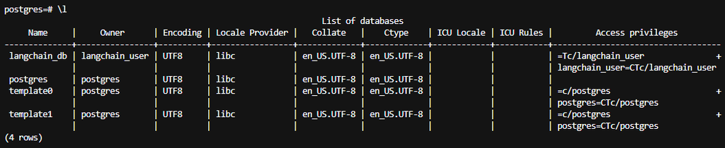

退出数据库终端 输入 \q 回车

## 2.3 测试URL

开启一个新的终端，执行如下命令，用户名，ip，端口，数据库名称 本地访问  
psql "postgresql://langchain_user:abcd1234@localhost:5432/langchain_db?sslmode=disable"

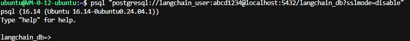

## 2.4 远程服务器链接额外操作

### 2.4.1 安全组放通5432端口

在安全组管理页面添加规则

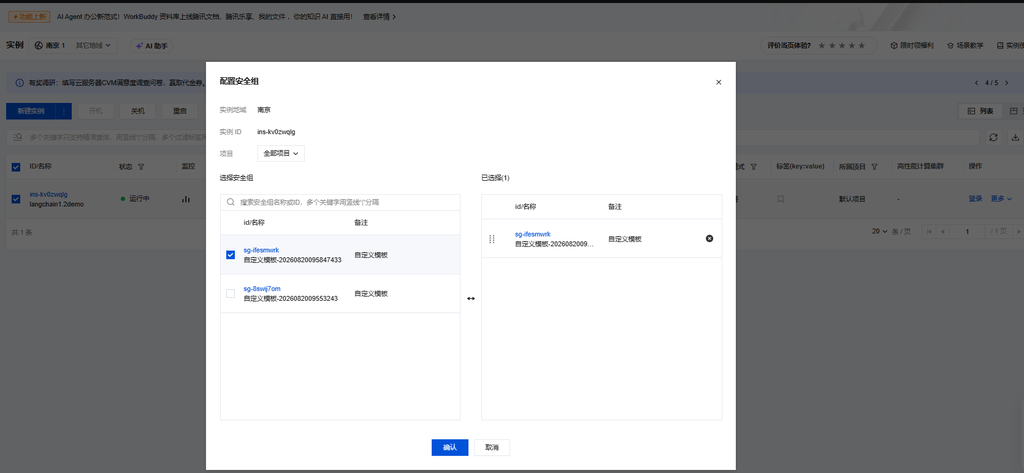

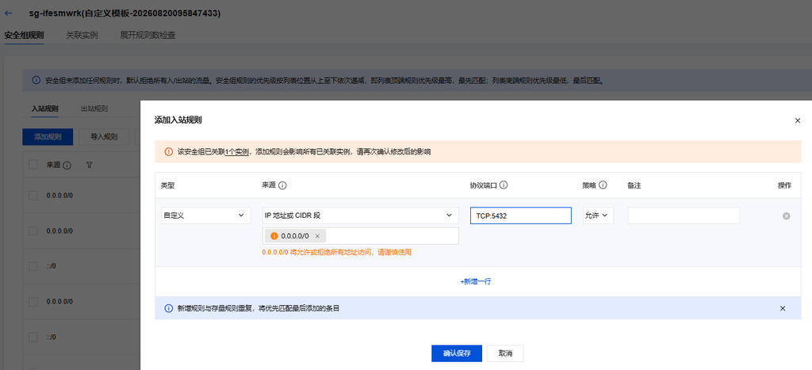

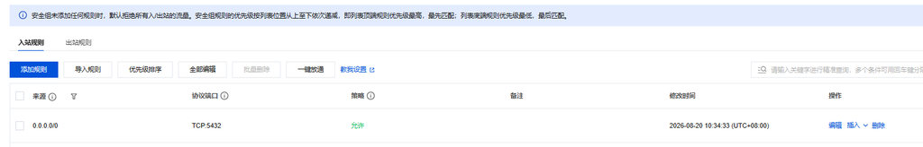

### 2.4.2 PostgreSQL监听所有IP

默认情况PosrgresSQL只允许来自本地的请求，需要更改其listen_addresses

#### 1）查看相关配置文件路径

Ubuntu命令行执行命令

`sodu -u postgres psql -c "SHOW config_file;"`

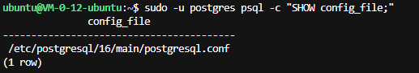

/etc/postgresql/16/main/postgresql.conf为配置文件路径

#### 2）更改配置文件

输入如下命令进入配置文件编辑  
`sudo vim /etc/postgresql/16/main/postgresql.conf`

找到`#listen_addresses = 'localhost'`  
按下yy，然后按下p复制一行  
打开复制那行的注释，将监听的IP替换为所有，如下  
`listen_addresss ='*'`

保存退出 esc :q

#### 3）重启服务

可以等下一步一起重启

### 2.4.3 添加允许规则

上一步放通了PostgreSQL对**网络的限制**，这一步放通**访问限制**

#### 1）查看配置文件路径

`sudo -u postgres psql -c "SHOW hba_file;"`

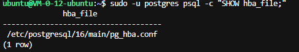

#### 2）更改配置文件

输入如下命令进入配置文件编辑  
`sudo vim /etc/postgresql/16/main/pg_hba.conf`

调到文件的最后  
i进入编辑模式，粘贴这段值：

```python
host    langchain_db    langchain_user  0.0.0.0/0               scram-sha-256
```

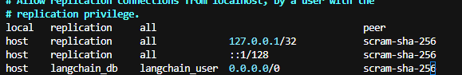

这表示放通所有IP通过langchain_user用户对于langchain_db数据库的访问权限  
保存退出 ESC ：q

`sudo systemctl reload postgresql.service`

#### 4）测试连接

从实例处可以看到分配的公网IP

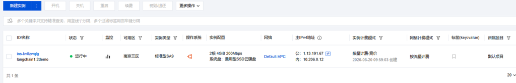

输入如下命令进行公网访问  
psql "postgresql://langchain_user:abcd1234@1.13.191.67:5432/langchain_db?sslmode=disable"

**注意用户名，密码，本机IP不同都需要相应修改**

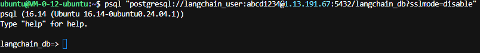